# ggmap: Spatial Visualization with ggplot2

### The `route` function

The `route` function provides the map distances for the sequence of “legs” which constitute a route between two locations. Each leg has a beginning and ending longitude/latitude coordinate along with a distance and duration in the same units as reported by `mapdist`. The collection of legs in sequence constitutes a single route (path) most easily plotted with `geom_leg`, a new exported *ggplot2* geom which is simply `geom_segment` with rounded ends.[^3]

A nice illustration of plotting routes with `geom_leg` can be seen in Figure 12 where three routes are plotted between the same two locations. These can be obtained using the `alternatives = TRUE` specification in `route`. `alternatives` requests more than one route from the origin to the destination; the returned value is again a data frame with an additional variable which serves as a route identifier (A, B, C, etc.).

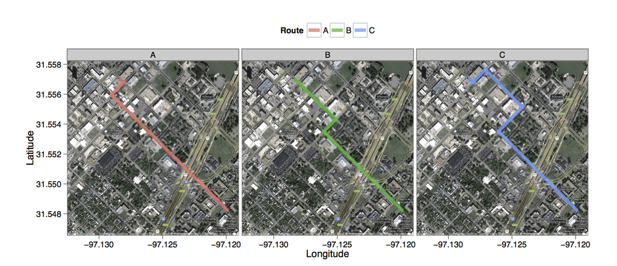

Figure 12: Three routes returned by route plotted with geom_leg.

```r
legs_df <- route(
  'marrs mclean science, baylor university',
  '220 south 3rd street, waco, tx 76701',
  alternatives = TRUE
)

qmap('424 clay avenue, waco, tx', zoom = 15, maptype = 'hybrid',
    base_layer = ggplot(aes(x = startLon, y = startLat), data = legs_df)) +
  geom_leg(
    aes(x = startLon, y = startLat, xend = endLon, yend = endLat,
        colour = route),
    alpha = 3/4, size = 2, data = legs_df
  ) +
  labs(x = 'Longitude', y = 'Latitude', colour = 'Route') +
  facet_wrap(~ route, ncol = 3) + theme(legend.position = 'top')
```

Like map distances, there are restrictions on the limit of routes which can be requested in a given period of time as well. The number of queries left is monitored by the `.GoogleRouteQueryCount` variable with the `routeQueryCheck` function.

# Plotting shape files

As a final example which is perhaps too common to ignore, plotting shape files with *ggmap* is a breeze and can be done in several ways. The easiest way is to convert the shape file to a data frame with `fortify` (*ggplot2*) and then add a point/path/polygon layer to the map, depending on what the contents of the shape file are (note that `fortify` does not yet have methods for all shape files). Additional layers can be added by simply layering on more `geom` layers. Figure 13 shows a basic example of plotting the U.S. Census 2000 census tracts along with complete code (U.S. Census Bureau, Geography Division, Cartographic Products Management Branch 2001).

[figure not shown]

Figure 13: Plotting shape files – Census tracts in Texas from the 2000 U.S. Census.

```r
# get an example shape file
download.file('http://www.census.gov/geo/cob/bdy/tr/tr00shp/tr48_d00_shp.zip',
  destfile = 'census.zip')

# unzip, and load tools
unzip('census.zip'); library(maptools); library(gpclib); library(sp);
gpclibPermit()

# read data into R
shapefile <- readShapeSpatial('tr48_d00.shp',
  proj4string = CRS("+proj=longlat +datum=WGS84"))

# convert to a data.frame for use with ggplot2/ggmap and plot
data <- fortify(shapefile)
qmap('texas', zoom = 6, maptype = 'satellite') +
  geom_polygon(aes(x = long, y = lat, group = group), data = data,
    colour = 'white', fill = 'black', alpha = .4, size = .3)
```

# Conclusion and future directions

Building on top of *ggplot2*, *ggmap* provides several new useful tools for visualizing spatial data. Theoretically speaking, the layered grammar of graphics attempts to enforce plotting consistency and therefore good plotting practice. Practically speaking, building *ggmap* on *ggplot2* makes the result even better as the full range of *ggplot2* capabilities can be brought to bear.

There are a number of future directions in store for *ggmap*. The new [*osmar*](https://CRAN.R-project.org/package=osmar) package integrates R and the OpenStreetMap data structures with which OpenStreetMap maps, Stamen Maps, and CloudMade Maps are rendered, thereby opening a floodgate of possibilities for plotting geographic objects on top of maps or satellite imagery all within R using *ggmap* (Eugster and T. Schlesinger 2013). Alternatively, integration with other spatial packages in R could provide several incredibly useful practical tools for spatial data analysis. Finally, the Google Elevation API and Places API provide additional interesting frontiers which can be incorporated into the *ggmap* framework just like the other Google APIs to give users additional capabilities though freely available geographical data.

# Acknowledgment

The authors would like to thank Jean-Olivier Irisson for his comments.

Becker, R. A., A. R. Wilks, R. Brownrigg, and T. P. Minka. 2013. *Maps: Draw Geographical Maps*. http://CRAN.R-project.org/package=maps.

Bivand, R., and N. Lewin-Koh. 2013. *Maptools: Tools for Reading and Handling Spatial Objects*. http://CRAN.R-project.org/package=maptools.

Bivand, Roger S., Edzer J. Pebesma, and Virgilio Gómez Rubio. 2008. *Applied Spatial Data: Analysis with R*. New York: Springer. http://www.asdar-book.org/.

Couture-Beil, Alex. 2013. *Rjson: JSON for R*. http://CRAN.R-project.org/package=rjson.

Eugster and T. Schlesinger, M. J. A. 2013. *osmar: Openstreetmap and R*. The R Journal 5 (1).

Fellows, I., A. Rickett, and N. Fultz. 2013. *DeducerSpatial: A Deducer Plug-in for Spatial Data Analysis*. http://CRAN.R-project.org/package=DeducerSpatial.

Loecher and Berlin School of Economics and Law, M. 2013. *RgoogleMaps: Overlays on Google Map Tiles in R,* . R package version 1.2.0.3. http://CRAN.R-project.org/package=RgoogleMaps.

Pebesma, E. J., and R. S. Bivand. 2006. “Classes and Methods for Spatial Data in R.” *R News* 5 (2). http://cran.r-project.org/doc/Rnews/.

U.S. Census Bureau, Geography Division, Cartographic Products Management Branch. 2001. *Census 2000: Census Tract Cartographic Boundary Files*. http://www.census.gov/geo/www/cob/tr2000.html.

Wickham, H. 2009. *ggplot2: Elegant Graphics for Data Analysis*. Springer New York. http://had.co.nz/ggplot2/book.

———. 2010. “A Layered Grammar of Graphics.” *Journal of Computational and Graphical Statistics* 19 (1): 3–28.

Wickham, Hadley. 2011. “The Split-Apply-Combine Strategy for Data Analysis.” *Journal of Statistical Software* 40 (1): 1–29. http://www.jstatsoft.org/v40/i01/.

Wilkinson, L. 2005. *The Grammar of Graphics*. New York: Springer.

[^1]: Note that because of the Mercator projection limitations in `mapproject`, anything above/below $\pm80^{\circ}$ cannot be plotted currently.
[^2]: As an example, the reader is referred to look at Google Maps satellite images of northwest tributaries to Lake Waco and search for them in the Stamen watercolor tile set.
[^3]: This was inspired by the beautiful work of J. Cheshire available at http://spatialanalysis.co.uk/2012/02/great-maps-ggplot2/.